# Weekly update for September 18

## Show and Tell September 18

## Unnamed’s Slides

## Sample List

- This
- Is
- Sparta!!
- (And *Sparta* in Italics)
- (And **Sparta** in bold)
- (And *Sparta* in bold Italics)
- (And Sparta with a link)

## Sample Image

[figure not shown]

## Sample Table with Equations

For me (Guillermo), it’s been a nightmare to type equations and tables in RMarkdowns. But you can try…

[output not shown]

## Sam’s Slides

## Judge education and outreach

- Phone call with Alicia and some other awesome people:
  - Judge Barbara Hervey
  - Judge Stephanie Domitrovich
  - Felice Schur, Assoc. Dir., Judicial Div., ABA
- Devise a course to teach statistics to judges
  - Use cases where statistical testimony has been / could be used
  - Focus on concepts, not equations
  - Ballistics, fraud, paternity, discrimination, mixture DNA
  - e.g. U.S v. Glynn (2008) (ballistics)
- Work with Hal Stern at UCI

## Developing more human factors studies

- Using ULTR language in the evidence conditions
- Describing the ULTR language as approved by the FBI or not
- Telling participants the known error rates or not (where applicable)
- More evidence conditions: mixture DNA, ballistics, fingerprints
- Including the statement below as a condition:

> Even though these two items are indistinguishable, we do not know how many other items would have also been indistinguishable from the crime scene evidence."
- Work with Bill Thompson at UCI.

## Soyoung’s slides

## Soyoung’s slides

- Working on many comparisons between known matches (replicates)
- There are 10 possible pairwise comparisons for 5 replicated images
- Example. Comparison between rep2 and rep3

## Soyoung’s slides

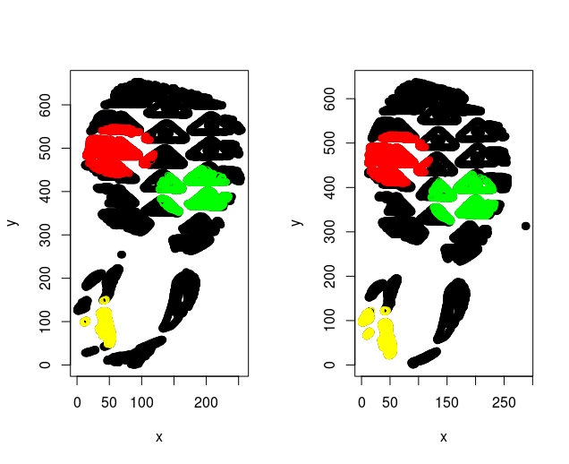

## Soyoung’s slides

- Example. Comparison between rep2 and rep3

| Circle | Fixed_circle_X | Fixed_circle_Y | Match_circle_X | Match_circle_Y |
| --- | --- | --- | --- | --- |
| Circle1 | 64.75 | 493.6 | 63.5 | 464.0 |
| Circle2 | 64.75 | 100.0 | 32.5 | 71.5 |
| Circle3 | 181.30 | 400.0 | 178.5 | 375.0 |

| Match_circle_Radius | Rotation_angle | Input_circle_overlap_pct | Triangle_sides |
| --- | --- | --- | --- |
| 56.34 | 0.8441 | 0.9943 | A-B |
| 53.45 | 0.3165 | 0.9721 | A-C |
| 57.24 | 0.000 | 0.8855 | B-C |

## Example

| Fixed_circle_side_length | Match_circle_side_length |
| --- | --- |
| 393.60 | 393.72 |
| 149.48 | 145.42 |
| 321.84 | 336.80 |

## Soyoung’s slides

- Get the results of 20 comparisons (2 pairs)
- The goal is to find similarity attributes as many as possible
- Euclidean distance of centers from 3 circles,
- Average of Overlap features,
- Standard deviation of rotation angle estimations.

## Soyoung’s slides

| Summary | Mean_overpt | Diff_ecd | sd_rot |
| --- | --- | --- | --- |
| MIN. | 0.8481 | 0.9532 | 0.1432 |
| 1st. Qu. | 0.8938 | 5.0380 | 0.3872 |
| Median | 0.9450 | 6.1066 | 0.5684 |
| 3rd. Qu. | 0.9670 | 10.5957 | 0.9506 |
| Max. | 0.9788 | 20.5656 | 2.2501 |

## Martin and Guillermo’s slides

## Image Alignment

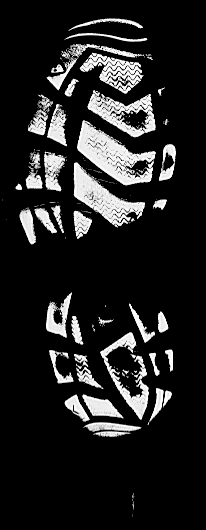

[figure not shown]

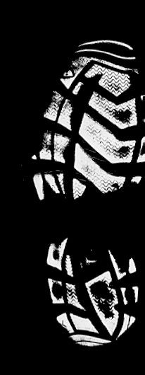

## Forgotten Image from Last Week

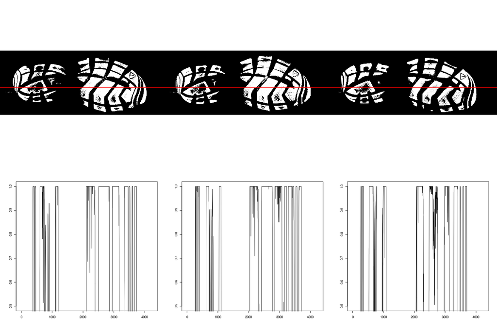

## Nick’s Slides

## London With Nodes

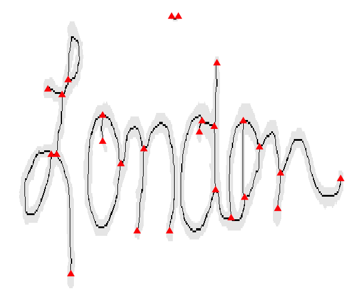

## London As Graph

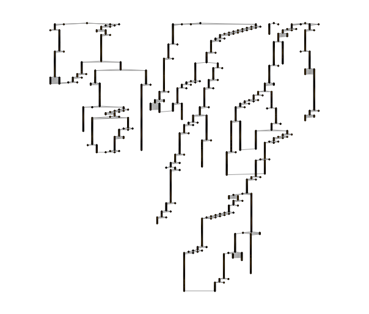

## Jason’s Slide

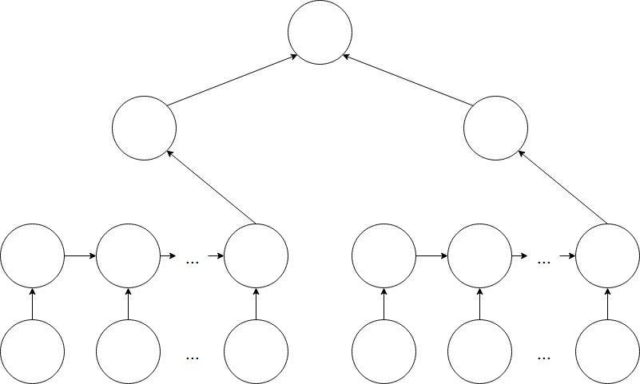

- Re-implemented, then re-re-implemented the above model
- Attempted to code poorly-specified steganalysis models
- Learned that being a Bayesian in neural network-land is pretty darn simple
- [Introduction to Neural Networks for Statisticians](https://nbviewer.jupyter.org/github/jsaporta/Notebooks/blob/master/Notebooks/Neural%20Networks%20for%20Statisticians.ipynb)

## Heike’s slide

- visit from Srinivasan Rathinam from LA PD
- processing scans from Berettas
- upload Phoenix data to local DB

## Amy’s Slides

## FlashID Exported Measurements

- 3 writers, 3 documents each (REU data: London and Cedar letters)

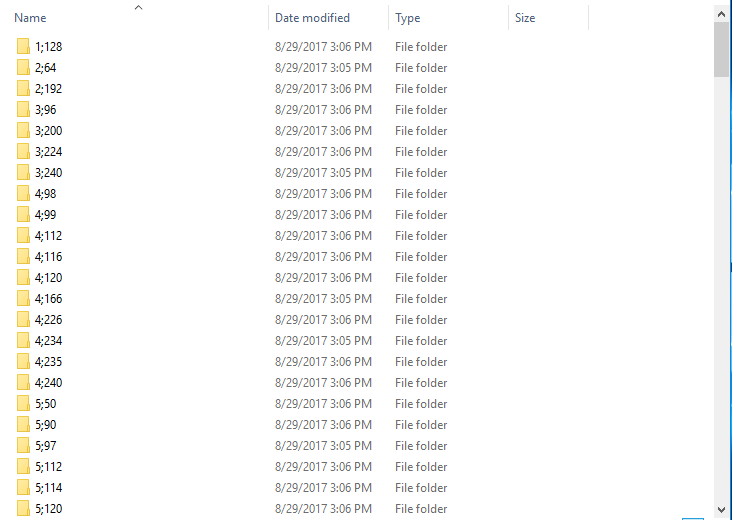

## FlashID Exported Measurements

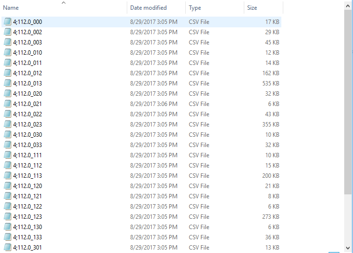

## FlashID Exported Measurements

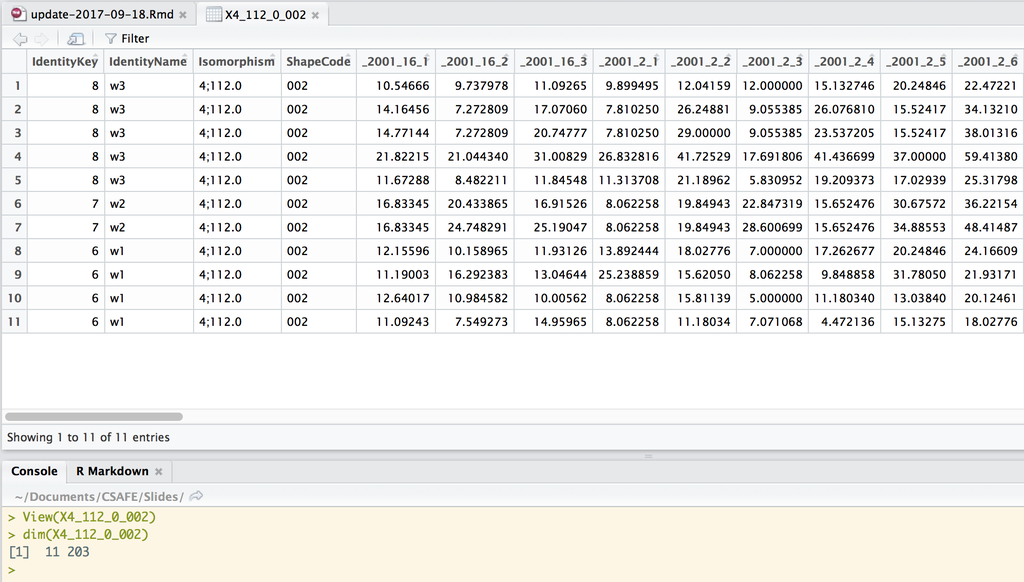

## The Plan

- Each file will have a number of columns that depend on the graph being measured.
- Moving forward
  - Extract grapheme counts
  - Re-create the FlashID scoring
  - Grapheme importance & feature importance (number of features varies by grapheme type)
- **This week**: Science Bound Forensics Session (Saturday, Sept. 23)
  - Overview, handwriting, and fingerprints